# Quadratic Programming and The Efficient Frontier

Read in data using `read.csv()`. You can drop the file into the current working directory and type the path, which in this case is, `read.csv("monthly_returns.csv")`. If you don’t know the path to the file, type `read.csv(file.choose())` to bring up a file menu. You can get the file from this link here: http://www.fdrennan.net/pages/pages2/monthly_returns.csv.

```r
monthly_returns = read.csv("monthly_returns.csv")
```

You can see below that there is a date column. Let’s remove this column before proceeding. This will make our code look a bit cleaner given that the data is no longer necessary.

```r
head(monthly_returns)
```

```
##        DATE        SPY        VEA        BND        TIP        SHV
## 1 6/30/2016  0.0034674 -0.0206166  0.0199984  0.0219237  0.0010010
## 2 5/31/2016  0.0168646 -0.0030010 -0.0000678 -0.0064623 -0.0000718
## 3 4/29/2016  0.0039374  0.0228692  0.0040780  0.0020913  0.0005451
## 4 3/31/2016  0.0650782  0.0694866  0.0087454  0.0165351  0.0003625
## 5 2/29/2016 -0.0008304 -0.0313303  0.0084834  0.0121343  0.0003544
## 6 1/29/2016 -0.0510646 -0.0568701  0.0119393  0.0155603  0.0007256
```

```r
# Remove date column
monthly_returns = monthly_returns[,-1]
```

Next, we’ll find the average yearly return. We can do this by summing the monthly log returns and taking the average multiplied by 12. To sum over columns in R, use the `apply()` function. Type `?apply` for documentation. The three parameters that the function takes are as follows `apply(data_frame, MARGIN, function)`. Margin can take the value of 1 or 2. 1 means to apply the function over rows and 2 specifies applying the function over columns. Given that returns are in columns, we will use 2.

```r
n_per = 12

# average_yr_ret from HW
average_yr_ret = apply(monthly_returns, 2, mean)*n_per
names(average_yr_ret) = colnames(monthly_returns)

average_yr_ret
```

```
##        SPY        VEA        BND        TIP        SHV
## 0.11313380 0.01983340 0.03622642 0.02490008 0.00064168
```

```r
# Lets get the standard deviation of each stock's monthly returns.
sd_returns = apply(monthly_returns, 2, sd)

# mu from HW
variance_monthly_returns = apply(monthly_returns, 2, var)/2

# Convert from monthly to yearly with n_per,
# add average_yr_ret to get average expected return.
mu = variance_monthly_returns*n_per + average_yr_ret
```

R makes it really easy to make a correlation table. If you have a data-frame of values (a data-frame is just a table of values like an excel spreadsheet) or a matrix of values, simply throw them into the `cor()` function.

```r
# Correlation table from HW
correlation_matrix = cor(monthly_returns)
```

In order to get an average correlation, we’ll use the formula below when $n$ is the number of stocks in the correlation matrix. We’ll get $n$ from using `nrow()` or `ncol()`. In this case, we can use `nrow(cor(monthly_returns))` where `correlation_matrix = cor(monthly_returns)`:

$$\hat{\rho}= \frac{\sum_{i=1}^n\sum_{j=1}^n\rho_{ij}-n}{n^2-n}$$

```r
# Calculation mu_correlation from HW
n_row_correl = nrow(correlation_matrix)
mu_correlation = (sum(correlation_matrix) - n_row_correl)/(n_row_correl^2 - n_row_correl)
```

Here we will create a forcasted correlation matrix. Because I do not yet know the matrix algebra involved to create it, I’m using a loop to fill in the values. The forcast matrix will allow us to have a predicted variance for the portfolio.

```r
forcast_mat = matrix(NA, nrow = n_row_correl, ncol = n_row_correl)
for(i in seq_along(sd_returns)) {
     forcast_mat[i,] = sd_returns[i]*mu_correlation*sd_returns*n_per
}

diag(forcast_mat) = apply(monthly_returns, 2, var)*n_per
```

If you are in my porfolio class, all of the data you have seen prior is familar. We did this in Excel. Just to prove it, I’ll show you.

```r
data.frame("Average Expected Return" = mu, "Standard Deviation of Returns" = sd_returns)
```

```
##     Average.Expected.Return Standard.Deviation.of.Returns
## SPY            0.1203732785                  0.0347358569
## VEA            0.0316608797                  0.0443987232
## BND            0.0366597781                  0.0084986089
## TIP            0.0262163765                  0.0148115748
## SHV            0.0006420472                  0.0002474019
```

```r
cor(monthly_returns)
```

```
##             SPY        VEA        BND        TIP        SHV
## SPY  1.00000000  0.8722063 -0.1760239 0.01406812 -0.2076687
## VEA  0.87220629  1.0000000 -0.1049595 0.11654043 -0.1485847
## BND -0.17602389 -0.1049595  1.0000000 0.84071614  0.3060131
## TIP  0.01406812  0.1165404  0.8407161 1.00000000  0.1615002
## SHV -0.20766870 -0.1485847  0.3060131 0.16150023  1.0000000
```

```r
round(forcast_mat, 6)
```

```
##          [,1]     [,2]     [,3]     [,4]    [,5]
## [1,] 0.014479 0.003098 0.000593 0.001033 1.7e-05
## [2,] 0.003098 0.023655 0.000758 0.001321 2.2e-05
## [3,] 0.000593 0.000758 0.000867 0.000253 4.0e-06
## [4,] 0.001033 0.001321 0.000253 0.002633 7.0e-06
## [5,] 0.000017 0.000022 0.000004 0.000007 1.0e-06
```

### Quadratic Programming

Next, in order to minimize variance subject to particular constraints, we need to install a package called `quadprog`. Do this bu running the code `install.packages("quadprog")` like below and then load the package by typing `library(quadprog)`. If you aren’t familiar with packages, these are simply collections of code written by other individuals for a particular task. In out case here, non-linear optimization.

```r
install.packages("quadprog")
```

We will use the function `solve.QP` from the `quadprog` package. According to the R documentation, the function `solve.QP` implements the dual method of Goldfarb and Idnani (1982, 1983) for solving quadratic programming problems of the form:

$$min\:\ {-d^Tb} + 0.5b^TDb \\
s.t.\; A^Tb\geq b_0$$

OK, what the hell does that mean. $D$ is the matrix appearing in the quadratic function to be minimized. $d$ is a vector appearing in the quadratic function to be minimized. $A$ is a matrix defining the constraingts under which we want to minimize the quadratic function. $b$ is a vector holding the values of $b_0$, which default to $0$.

Let’s look at what this means in more detail. First, the $D$ matrix.

If you look at the equation above, you’ll see $0.5v^TDb$, well in order to compensate for the $0.5$ in the equation, we’ll multiply our $D$ matrix by $2$. I honestly don’t know why this is, or what it means. I’m just trying to get you to be able to minimize the variance of a portfolio and people way smarter than me said this is how you do it.

```r
# Create a_matrix
d_mat <- 2*correlation_matrix
```

The next two rows force the sum of $x_1...x_n$ to be exactly equal to $1$. We need to include a negative line (third row) because we require positive values for $x_1...x_n$. Without the negative row, you can’t create proportions. The optimization function is looking at values greater than or equal in the $A$ matrix, so we force $x_1...x_n$ to 1 using the negative concurrently with the positive.

The diagonal, beginning in line 4 forces all weights to be greater than $0$. That is, we are not going to short in this case.

$$\begin{bmatrix}
.1203 & .0316 & .0366 & .0262 & .0006 \\
1 & 1 & 1 & 1 & 1 \\
-1 & -1 & -1 & -1 & -1 \\
1 & 0 & 0 & 0 & 0 \\
0 & 1 & 0 & 0 & 0 \\
0 & 0 & 1 & 0 & 0 \\
0 & 0 & 0 & 1 & 0 \\
0 & 0 & 0 & 0 & 1 \\
\end{bmatrix}
\begin{bmatrix}
x_1 \\
x_2 \\
x_3 \\
x_4 \\
x_5 \\
\end{bmatrix}
\geq
\
\begin{bmatrix}
.1 \\ 1 \\ -1 \\ 0 \\ 0 \\ 0 \\0 \\ 0
\end{bmatrix}$$

```r
# Creating the A matrix
proportion_vector <- rep(1, n_row_correl)
diag_matrix <- diag(1, length(mu))
A_mat = rbind(mu, proportion_vector, -proportion_vector, diag_matrix)

# Creating the b vector
b_vec = c(.1, 1, -1, rep(0, n_row_correl))

# Show the A_mat and b_vec together
cbind(A_mat, b_vec)
```

```
##                          SPY         VEA         BND         TIP
## mu                 0.1203733  0.03166088  0.03665978  0.02621638
## proportion_vector  1.0000000  1.00000000  1.00000000  1.00000000
##                   -1.0000000 -1.00000000 -1.00000000 -1.00000000
##                    1.0000000  0.00000000  0.00000000  0.00000000
##                    0.0000000  1.00000000  0.00000000  0.00000000
##                    0.0000000  0.00000000  1.00000000  0.00000000
##                    0.0000000  0.00000000  0.00000000  1.00000000
##                    0.0000000  0.00000000  0.00000000  0.00000000
##                             SHV b_vec
## mu                 0.0006420472   0.1
## proportion_vector  1.0000000000   1.0
##                   -1.0000000000  -1.0
##                    0.0000000000   0.0
##                    0.0000000000   0.0
##                    0.0000000000   0.0
##                    0.0000000000   0.0
##                    1.0000000000   0.0
```

The $d$ vector is a vector of the average returns for each security. To find the minimium portfolio variance, we set these all to zero.

```r
# create d_vector
d_vector = rep(0, length(mu))
```

```r
library(quadprog)

sol = solve.QP(d_mat, d_vector, t(A_mat), b_vec)
sol$solution = round(sol$solution, 5)
names(sol$solution) = names(mu)

mu_tenp = sol$solution%*%mu
var_tenp = t(sol$solution)%*%forcast_mat%*%sol$solution
sd_tenp = sqrt(var_tenp)
```

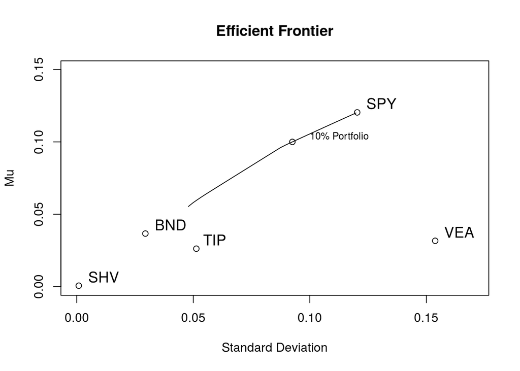

```r
library(quadprog)
# create b vector
sd_vector <-  vector()
mu_vector <- vector()
j = 1
for(i in seq(0, max(mu), .002)) {
     b_vec = c(i, 1, -1, rep(0, n_row_correl))

     sol = solve.QP(d_mat, d_vector, t(A_mat), b_vec)

     sol$solution = round(sol$solution, 5)
     names(sol$solution) = names(mu)

     mu_portfolio = sol$solution%*%mu
     var_portfolio = t(sol$solution)%*%forcast_mat%*%sol$solution
     sd_portfolio = sqrt(var_portfolio)

     # if(i == min(mu)) {
     #      plot(sd_portfolio, mu_portfolio, xlim = c(sd_portfolio-.01, .15), ylim = c(min(mu), max(mu)), xlab = "Standard Deviation", ylab = "Mu")
     # }
     #
     #
     # points(sd_portfolio, mu_portfolio)
     sd_vector[j] <- sd_portfolio
     mu_vector[j] <- mu_portfolio
     j = j +1
}
library(calibrate)
plot(sd_vector, mu_vector, main = "Efficient Frontier", xlab = "Standard Deviation", ylab = "Mu", type = "l", xlim = c(0, .17), ylim = c(0, .15))
points(sqrt(diag(forcast_mat)), mu)
textxy(sqrt(diag(forcast_mat)), mu, names(mu), cex = 1.2)
points(sd_tenp, mu_tenp)
textxy(sd_tenp, mu_tenp, "10% Portfolio", cex = .8, offset = .8)
```